# SAE_Maths_Lo_Bellagraa_Final

Coloration : algorithme de Brélaz

- Yassine BELLAGRAA
- Faty LO

Dans le cadre de la **SAE202 : Exploration algorithmique d'un problème**, il nous a été demandé de réaliser un projet mathématique et informatique.  
Après concertation avec notre enseignante *Laila BAROUKH*, nous avons choisi de réaliser le projet :

> Coloration : algorithme de Brélaz

.

Voici la description qui a été donnée :

- **Niveau de difficulté** : ☆☆
- **Description** : Nous avons vu en cours un algorithme heuristique permettant d'estimer le nombre chromatique d'un graphe non orienté.
- **Animation** : la coloration des différents sommets d'un graphe.

L'objectif principal de cette SAE est de réaliser une ou plusieurs animations pour répondre au problème posé. Pour cela, nous avons réalisé le TP dédié (disponible en ligne [ici](https://www.ataraxy.info/COEUR/Modules/MethodesNumeriques/TP/Graphiques%20et%20animations-CORRECTION.html)).

Nous avons travaillé environ 21 h sur ce projet et avons réparti le travail comme suit :

- **Yassine** : visualisations, explications théoriques et notions Python à utiliser
- **Faty** : réalisation des tests et des fonctions en Python

Cependant, nous avons réalisé ensemble les tâches suivantes :

- Réalisation des animations
- Calcul du temps moyen de l'algorithme
- Réalisation de l'algorithme
- Mise en forme et compréhension du sujet

Sources

- Les cours de M. Hébert sur la théorie des graphes : https://ataraxy.info/Graphes
- Cours d'Amphi de 2021 de M. Hébert sur le coloriage des graphes : https://ataraxy.info/COEUR/Modules/Graphes/Cours/Videos/Amphi04.mp4
- Page Wikipédia sur la coloration de graphe : https://fr.wikipedia.org/wiki/Coloration_de_graphe
- Le site de la bibliothèque Python 'NetworkX' : https://networkx.org/
- Le cours sur la complexité de l'IUT de Villetaneuse : https://github.com/iutVilletaneuseDptInfo/R101_2/blob/main/2_complexite/cours_complexite.ipynb
- Réponse sur le site Stackoverflow pour avoir des sommets à position fixe: https://stackoverflow.com/questions/30035039/fix-position-of-subset-of-nodes-in-networkx-spring-graph

Bibliothèques

Nous aurons besoin de plusieurs bibliothèques pour exécuter nos programmes.

```python
#Fonction aléatoire
from random import random

#Fonction de graphique et d'animation
import networkx as nx
import matplotlib.pyplot as plt
from matplotlib import animation
from IPython.display import HTML

#Fonction de temps
from time import time
```

Présentation de l'algorithme

**Francis Guthrie**, mathématicien et botaniste, s'est demandé s'il était possible de colorier la carte d'Angleterre de telle sorte à ce que les villes adjacentes à une ville n'aient pas la même couleur.  
Il s'est particulièrement intéressé à la possible d'avoir le plus petit nombre de couleurs pour colorier cette carte.

Cela a donné naissance à un nouveau algorithme **heuristique** pour *estimer* la valeur du nombre chromatique afin d'avoir une bonne majoration de celui-ci. Nous reviendrons plus tard sur la définition du nombre chromatique.

Présentation de l'algorithme de Brélaz ou DSATUR :

> DSATUR est une heuristique qui consiste à colorer les sommets les uns après les autres, en s'appuyant sur un tri préalable des sommets. Une priorité est donnée aux sommets de grand degré, ainsi que les sommets dont les voisins ont déjà obtenu le plus de couleurs différentes.

Graphe non orienté

On utilisera très souvent la fonction `dessineGraphe` pour représenter des sommets, des arêtes, des graphes dans une sorte de schéma avec un titre.  
Elle prendra en paramètre un graphe et le titre de ce graphe et les couleurs des sommets (par défaut, ils sont blancs).  
Nous estimons qu'il n'est pas nécessaire d'expliquer les détails de cette fonction dans le but de faciliter la lecture de ce compte-rendu.

```python
def dessineGraphe(graphe, titre_dessin, couleurs="white"):
    fig = plt.figure(facecolor="lightgrey", dpi=100)
    ax1 = fig.add_axes([0,0,0.9,0.9])
    ax1.set_title(titre_dessin)
    nx.draw_networkx(graphe, ax=ax1, arrows=None, with_labels=True, node_color=couleurs, edge_color='black', node_size=200, font_size=10)
```

**Définition**  
Un **graphe non orienté $G$** est la donnée de :  
$(i)$ Un ensemble fini et non-vide noté **$Som(G)$** appelé les **sommets** du graphe **$G$**  
Par exemple : $Som(G) = $ {$a, b, c, d$}  
$(ii)$ Un ensemble noté **$Ar(G)$** appelé les **arêtes** du graphe **$G$** dont les éléments sont des ensembles formés de deux éléments de **$Som(G)$**  
Par exemple : $Ar(G) = $ { {$a,b$}, {$a,c$}, {$a,d$}, {$c,b$} }

Avant de se poser la question de la représentation d'un graphe non orienté, ne serait-il pas mieux de savoir avant comment représenter des sommets et des arêtes ?

### Sommets

Pour représenter des sommets, nous utiliserons les fonctions `Graph()` et `add_node()` de la bibliothèque NetworkX

`Graph()` permet de représenter un graphe "vide". Un graphe que l'on va remplir au fur et à mesure par des sommets et des arêtes.  
`add_node()` nous donne la possibilité d'ajouter des sommets à un graphe vide ou un graphe contenant déjà quelques sommets et/ou arêtes.

```python
def sommet(N):
    """
    Cette fonction permet de créer un graphe avec N sommets
    (sans arêtes)
    """
    G = nx.Graph()
    for i in range(1, 6, 1):               # génère des nombres de 1 à 5 (6-1) avec un pas de 1
        G.add_node(i)                      # ajoute un sommet au graphe vide
        name = '$x_'+str(i)+'$'
        G = nx.relabel_nodes(G, {i: name}) # renommer un sommet sous la forme x_i
    return G                               # retourner le nouveau graphe
```

Nous pouvons réaliser un test pour un graphe à 5 sommets :

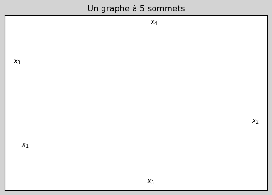

```python
# Test
G = sommet(5)
dessineGraphe(G, "Un graphe à 5 sommets")
```